# eigenletters_project

Philip Booth Fall 2024

CS 251 / 252: Data Analysis and Visualization

Project 4: Principal Component Analysis

#### Roadmap:

Principal Component Analysis (PCA) is a powerful tool that captures the patterns in data while reducing dimensionality. In this notebook, I apply my custom implementation of PCA to the EMNIST letter dataset. For more details about the EMNIST dataset, visit the official page here. You can also find the implementation of my pca.py file on my GitHub repository.

```python
import numpy as np
import matplotlib.pyplot as plt
import pandas as pd

import pca

plt.style.use(['seaborn-v0_8-colorblind', 'seaborn-v0_8-darkgrid'])
plt.rcParams.update({'font.size': 20})

np.set_printoptions(suppress=True, precision=5)

# Automatically reload external modules
%load_ext autoreload
%autoreload 2
```

## Eigenletters — PCA on images of hand-drawn letters

Here, you will implement an algorithm that uses eigenvectors to reconstruct images based on how the deviate from the mean (i.e. average) image in a library of images. The original algorithm was applied to human faces (here is a [link](https://sites.cs.ucsb.edu/~mturk/Papers/jcn.pdf) to original paper), but we are going to apply it to hand-written letters from the EMNIST data set ([link](https://www.nist.gov/itl/products-and-services/emnist-dataset))

### Load in the dataset of images of a letter

Run the code below to load in 4,800 images of a single letter (including lower and upper case versions). You can download the file for each letter separately. Change the letter to whichever letter you want (and file you downloaded).

```python
letter = 'p' # Of course I had to choose P
letter_imgs = np.load(f'data/emnist_letter_{letter}.npy')

print(f'There are {letter_imgs.shape[0]} letters. There should be 4800.')
print(f'Shape of images is are {letter_imgs.shape} letters. It should be (4800, 28, 28).')
```

```
There are 4800 letters. There should be 4800.
Shape of images is are (4800, 28, 28) letters. It should be (4800, 28, 28).
```

### 4b. Look at the letter data

In the cell below, fill in the function to create a 12x10 subplots grid of plots (*12 rows, 10 columns*). For showing the image, use [imshow](https://matplotlib.org/stable/api/_as_gen/matplotlib.pyplot.imshow.html):

Run the function to create the plot of the letters below, with the title "Original".

**Note:**

- When you call `imshow`, add these optional parameters to create black-on-white images: `cmap='gray'`, `vmin=0`, and `vmax=255`
- Turn off the x and y ticks (they just add clutter).

```python
def plot_letter( letter_imgs, title ):
    '''Creates a 12x10 grid of grayscale letter images.

    Parameters:
    -----------
    letter_imgs: ndarray. shape=(N, img_y, img_x).
        Grayscale images to show.
    title: string
        Title to display above all the subplots

    '''
    fig, axs = plt.subplots(12,10)

    axs = axs.flatten()
    fig.suptitle(title)

    for i in range(len(axs)):
        axs[i].imshow(letter_imgs[i],cmap='gray', vmin=0,vmax=255)
        axs[i].set_xticks([])
        axs[i].set_yticks([])

    plt.show()
```

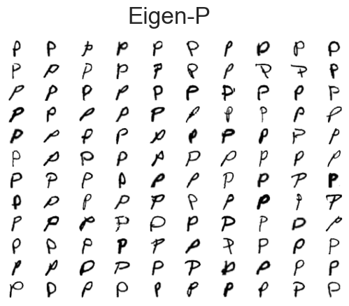

```python
# Call plot_letter
plot_letter(letter_imgs, 'Eigen-P')
```

### 4c. Visualize the "mean letter"

Take the mean of the images and show it below.

**Note:** Use the same `cmap`, `vmin`, and `vmax` parameters as above and turn off x and y tick marks.

```
(-0.5, 27.5, 27.5, -0.5)
```

[figure not shown]

```python
letter_img_mean = np.mean(letter_imgs, axis = 0)
plt.imshow(letter_img_mean,cmap='gray', vmin=0,vmax=255)
plt.axis('off')
```

### **Preprocess letter data**

In the letter dataset, each hand-written letter is a sample and each pixel is a variable. Currently, the latter data has shape = `(4800, 28, 28)` or $N = 4800$ samples and $M = 28*28 = 784$ pixels. To run PCA, we'll need to "unravel" each row of pixels and glue them into one big vector so that the shape = `(4800, 28*28)` = `(4800, 784)`. This will make a standard matrix and should work with your PCA code.

In the following cell, reshape the letter data **without hardcoding** ANY of (4800, 28*28)!

```python
# Your reshape code here
d1,d2,d3 = letter_imgs.shape
letter_imgs.shape

#
letter_img_reshaped = letter_imgs.reshape(-1, d2*d3)
print(letter_img_reshaped.shape)
```

```
(4800, 784)
```

### 4e. Perform PCA on preprocessed letter data

Create pandas DataFrame object that holds the letter data then run PCA on the letter dataset. The header names of consecutive integers `0, 1, ..., 783` are fine. For the `vars` parameter in the `fit` method, pass in a Python list of ints (`0, 1, ..., 783`).

**Notes:**

- This is not a "toy" dataset so it might take a few minutes for the PCA to finish computing.
- Use the python `time` module (i.e. `import time`) to time how long the `pca` method takes to finish processing the data, then print out the time elapsed below. If this takes more than a few minutes, something probably is wrong.
- When running the PCA, do not normalize the data. We do not want to treat each pixel as a separate feature.

```python
# Your code here
import time

letter_df = pd.DataFrame(letter_img_reshaped)
letter_pca = pca.PCA(letter_df)

start_time = time.time()
vars = list(range(784))
letter_pca.fit(vars, normalize_dataset=False)

finish_time = time.time()
total_elapsed = finish_time-start_time
print(f'total time:{total_elapsed}')
```

```
total time:0.2786381244659424
```

### 4f. Make letter PCA elbow plot

Make an elbow plot of the PCA results. Show **show only a reasonable number of PCs** to focus on the curve before it plateaus.

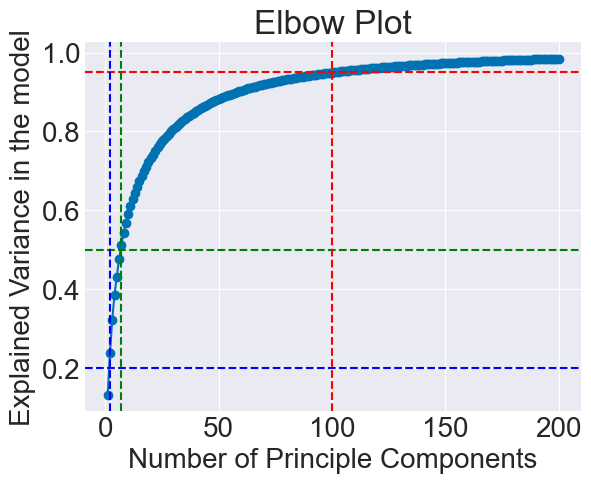

```python
# elbow plot code here

letter_pca.elbow_plot(200)
plt.axhline(y = 0.95, color = 'r', linestyle = '--')
plt.axhline(y = 0.50, color = 'g', linestyle = '--')
plt.axhline(y = 0.20, color = 'b', linestyle = '--')

plt.axvline(x = 100, color = 'r', linestyle = '--')
plt.axvline(x = 7, color = 'g', linestyle = '--')
plt.axvline(x = 2, color = 'b', linestyle = '--')
```

### 4g. Reconstruct letters using the principal components

Use your elbow plot to find the number of top principal components required to *approximately* explain the following cumulative proportion of the variance:

- 20%
- 50%
- 95%

Outline of the general process:

1. For each of the above number of PCs, project them back onto the original data space.
2. Write then use the below `make_imgs` function to convert the projected data back to image shapes `(4800, 28, 28)`.
3. Use `plot_letter` to plot the reconstructed 1st 120 letters with each of the variance numbers above.

**There should be 3 12x10 plots below**

```python
def make_imgs(reconstucted_imgs):
    '''Inflates a 1D feature vector representation of images into 2D images for plotting.
    Assumes square images

    Parameters:
    -----------
    reconstucted_imgs: ndarray. shape=(N, img_y*img_x)
        1D vector representation of each image

    Returns:
    -----------
    ndarray. shape=(N, img_y, img_x)
        The images inflated into 2D
    '''
    reconstruct = reconstucted_imgs.reshape(4800, 28,28)
    return reconstruct
```

#### Reconstructed letters with increasing accuracy

Reconstructed with 20% Accuracy

```
(4800, 28, 28)
(4800, 784)
```

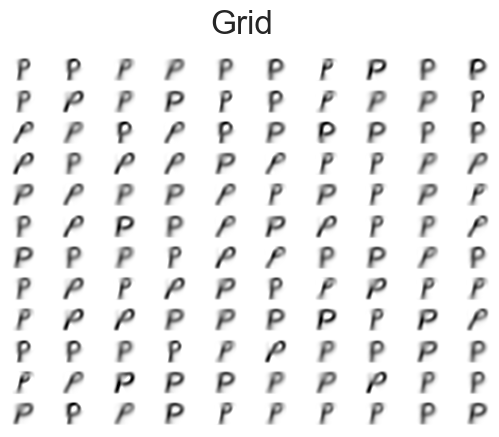

```python
# Your code here
reconstructed_imgs = letter_pca.pca_then_project_back(2)
rec_img = reconstructed_imgs.real
grid = make_imgs(rec_img)

print(letter_imgs.shape)
print(letter_img_reshaped.shape)

plot_letter(grid, 'Grid')
```

Reconstructed with 50% Accuracy

```
(4800, 28, 28)
(4800, 784)
```

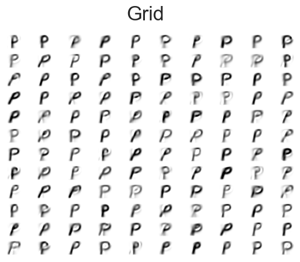

```python
# Your code here

reconstructed_imgs = letter_pca.pca_then_project_back(7)
rec_img = reconstructed_imgs.real
grid = make_imgs(rec_img)

print(letter_imgs.shape)
print(letter_img_reshaped.shape)

plot_letter(grid, 'Grid')
```

Reconstructed with 95% Accuracy

```
(4800, 28, 28)
(4800, 784)
```

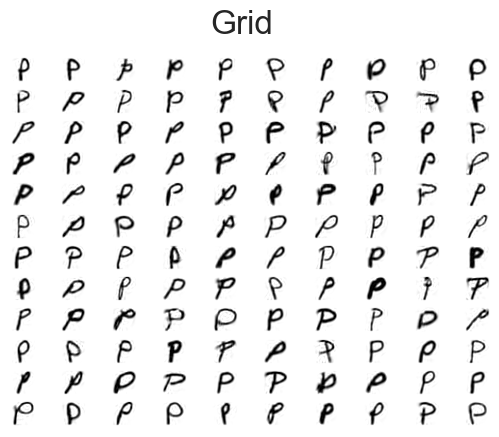

```python
# Your code here
reconstructed_imgs = letter_pca.pca_then_project_back(100)
rec_img = reconstructed_imgs.real
grid = make_imgs(rec_img)

print(letter_imgs.shape)
print(letter_img_reshaped.shape)

plot_letter(grid, 'Grid')
```

### 4h. Questions

**Question 12:** Pick one of the letter samples to focus on. Choose one that undergoes a visually interesting transformation as more eigenvectors are used in the reconstruction. Describe what happens visually to the same sample over the course of the reconstructions. Set up 5 plots in a row. The first should be the mean letter (because that is what we start from when we do the reconstruction). The next three should be just that sample with each level of reconstruction (from worst to best). The final plot should be the original data for that sample. Your description should have at least 5 sentences in it.

**Answer 12:**

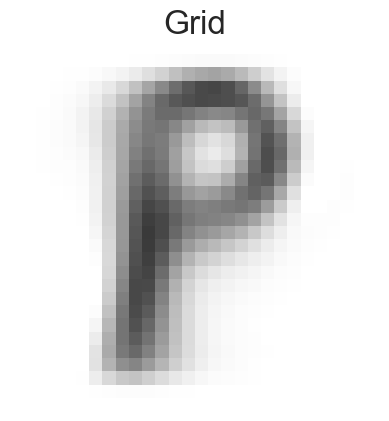

```python
oddp = letter_imgs[48]
def plot_single_letter( letter_imgs, title ):
    '''Creates a 12x10 grid of grayscale letter images.

    Parameters:
    -----------
    letter_imgs: ndarray. shape=(N, img_y, img_x).
        Grayscale images to show.
    title: string
        Title to display above all the subplots

    '''
    plt.title(title)
    plt.axis('off')
    plt.imshow(letter_imgs[75],cmap='gray', vmin=0,vmax=255)
    plt.show()
reconstructed_imgs = letter_pca.pca_then_project_back(1)
rec_img = reconstructed_imgs.real
grid = make_imgs(rec_img)
plot_single_letter(grid, 'Grid')
```

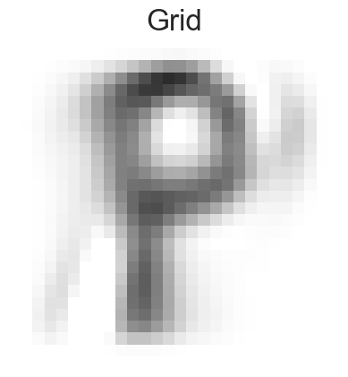

```python
reconstructed_imgs = letter_pca.pca_then_project_back(5)
rec_img = reconstructed_imgs.real
grid = make_imgs(rec_img)
plot_single_letter(grid, 'Grid')
```

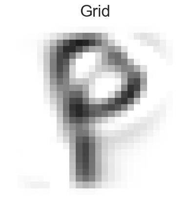

```python
reconstructed_imgs = letter_pca.pca_then_project_back(20)
rec_img = reconstructed_imgs.real
grid = make_imgs(rec_img)
plot_single_letter(grid, 'Grid')
```

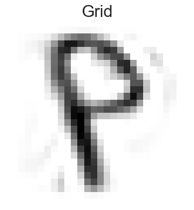

```python
reconstructed_imgs = letter_pca.pca_then_project_back(50)
rec_img = reconstructed_imgs.real
grid = make_imgs(rec_img)
plot_single_letter(grid, 'Grid')
```

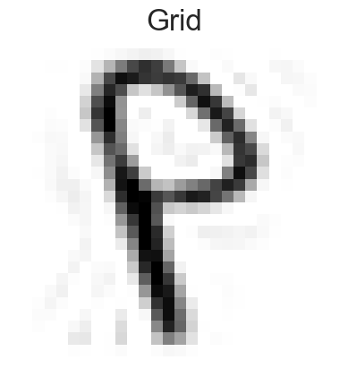

```python
reconstructed_imgs = letter_pca.pca_then_project_back(100)
rec_img = reconstructed_imgs.real
grid = make_imgs(rec_img)
plot_single_letter(grid, 'Grid')
```

The P on the 8th row and 6th column is drawn on a slant going up and to the left. For most the other p's they are drawn of the opposite slant, up and to the right. With each plot it feels as though the stem's angle is getting shifted from pointing in the direction of the average p towards the stem of this unorthodox one. In the second plot particularly you can almost see the motion in the image as it's transforming from the mean p towards the clearly projected p.

**Question 13:** Would it be effective to use the eigenvectors from one letter's data set to project and then project back (i.e. reduce and reconstruct) data from a different letter?

Either write several sentences with your reasoning or demonstrate it by writing the code to do it. If you do write the code, describe your output and write about whether or not you think your example is representative (e.g. how are your results dependent upon the two letters that you chose?)

**Answer 13:** This could work well depending on the letter. If two letters have similar structures such as P and R or C and G, then the principle components of one projected onto the other could do a solid job in recreating the data. However, take two letters that do not have similarities in their structures like q and l, then projecting principle components of one back onto the other letters would not do a good job at projecting that letter with reduced p-dimensions taken from the other letters.

## Extensions

### Guidelines

To receive credit for any extension, you must:

1. Not modify / prevent any code from the core project from working (e.g. make a copy before changing). In other words, **the notebook test code should still work!**
2. **You must describe what you did and what you found in detail**. This includes a summary of parameter values used in your simulations.
3. Include (*labeled!*) plots and/or numbers to present your results.
4. Write up your extensions below or in a separate notebook.
5. Give kudos to all sources, including anyone that you consulted.

Extension 1: For my extension I want to automate a way of learning what the optimal numbers of pc components should be. From what I've seen in class, I want to determine the principle components at 90% variability in the data and then from there project the data

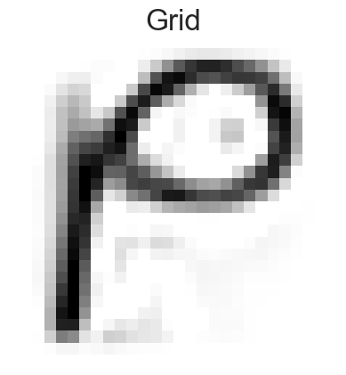

```python
def plot_single_letter( letter_imgs, title ):
    '''Creates a 12x10 grid of grayscale letter images.

    Parameters:
    -----------
    letter_imgs: ndarray. shape=(N, img_y, img_x).
        Grayscale images to show.
    title: string
        Title to display above all the subplots

    '''
    plt.title(title)
    plt.axis('off')
    plt.imshow(letter_imgs[110],cmap='gray', vmin=0,vmax=255)
    plt.show()
props = np.real(letter_pca.prop_var)
optimal_pc = letter_pca.find_num_pcs_for_variance(props, target_var=.9)
reconstructed_imgs = letter_pca.pca_then_project_back(optimal_pc)
rec_img = reconstructed_imgs.real
grid = make_imgs(rec_img)
plot_single_letter(grid, 'Grid')
```

As you can see the image is projected with 90% accuracy just as the optimal code found it. I also made it so that you can mess around with the target for more user interaction. Here is the grid with lower PC projection at 10% of variability.

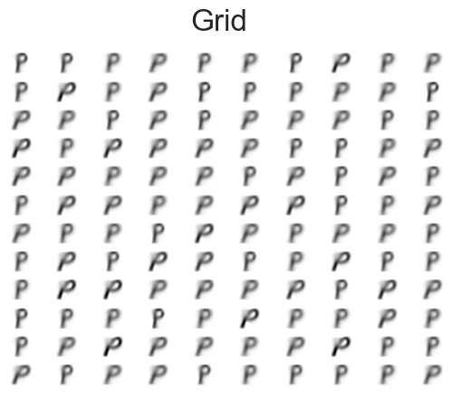

```python
props = np.real(letter_pca.prop_var)
lower_pc = letter_pca.find_num_pcs_for_variance(props, target_var=.1)
reconstructed_imgs = letter_pca.pca_then_project_back(lower_pc)
rec_img = reconstructed_imgs.real
grid = make_imgs(rec_img)
plot_letter(grid, 'Grid')
```

As you can see the method works to obtain your desired PC level. This is an alternative to the Elbow plot so that you do not need to necessarily load in the plot to figure out your desired outcome. The method that I implemented is in the PCA class. I also created an elbow_regression plot that can take the target from the find_num_pcs_for_variance method and project where on the elbow plot you will find it.

```
57
```

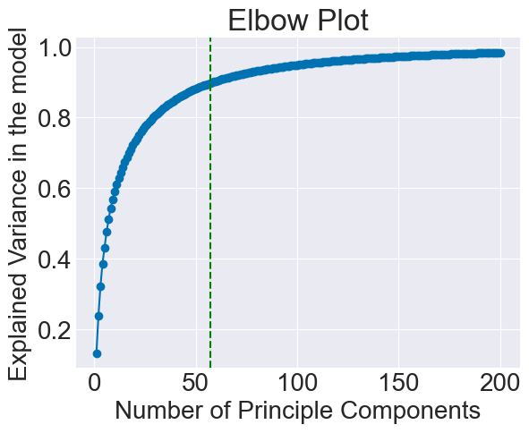

```python
letter_pca.elbow_plot_regression(200,target_slope=.002)
```